# Reducing Overfitting through Convolutional Neural Networks

A Case Study using the GTZAN Dataset

Beatrice Malvezzi

2025-02-17

# Introduction

Convolutional Neural Networks (CNNs) are a powerful tool for image classification tasks, yet overfitting is a challenge, especially when working with small datasets. The aim of this project is to explore some techniques to mitigate overfitting and improve the model generalization.

Using the GTZAN image dataset as a case study, several strategies were applied, including an initial hyperparameters tuning, leveraging a pre-trained model for feature extraction (VGG16) and applying regularization techniques including dropout.

Moreover, it was explored an alternative architecture structure, a Feed-forward Neural Network. However, it performed poorly suggesting that it is not well suited for this specific task.

# Description of the dataset

The dataset contains 1000 image and audio files evenly distributed into 10 different music genres (e.g. blues, classical, country, disco, …).

In this project the pre-processed image features, called spectrograms, are leveraged as input to train CNN models.

The spectrograms represent the frequency content of the audio over time so they can be useful when looking for frequency patterns that define the music genre.

The code is implemented using two powerful deep learning libraries: Keras and tensorflow. In particular Keras is an API developed with a focus on enabling fast experimentation.

```r
library(keras)
library(tensorflow)
```

# Project structure and data organization

The image files in PNG format are imported. The dataset was then divided into three subsets: 918 images for the training set, 280 for the test set and 273 for the validation set. Some transformations were applied in order to reach the RGB format (with 3 color channels) and the pictures were resized to 224x224 pixels.

```r
path <- "C:/Users/hp/Desktop/progetto statistical learning"

# Define the base and original dataset directories
original_dataset_dir <- "C:/Users/hp/Desktop/progetto statistical learning/images_original"

# Define base directory for splitting the dataset
base_dir <- "C:/Users/hp/Desktop/progetto statistical learning/images_base"
dir.create(base_dir)

# Create subdirectories for train, validation, and test sets
train_dir <- file.path(base_dir, "train")
dir.create(train_dir)
validation_dir <- file.path(base_dir, "validation")
dir.create(validation_dir)
test_dir <- file.path(base_dir, "test")
dir.create(test_dir)

genres <- list.files(original_dataset_dir)

train_datagen <- image_data_generator(rescale = 1/255)
test_datagen <- image_data_generator(rescale = 1/255)
validation_datagen <- image_data_generator(rescale = 1/255)

set.seed(123) # For replicability

# Distribution of images into train, validation and test directories
for (genre in genres) {
  genre_dir <- file.path(original_dataset_dir, genre)
  files <- list.files(genre_dir, full.names = TRUE)

  # Shuffle of files
  shuffled_files <- sample(files)

  # 70% train, 15% validation, 15% test
  train_split <- floor(0.7 * length(shuffled_files))
  validation_split <- floor(0.15 * length(shuffled_files)) + train_split

  train_files <- shuffled_files[1:train_split]
  validation_files <- shuffled_files[(train_split + 1):validation_split]
  test_files <- shuffled_files[(validation_split + 1):length(shuffled_files)]

  # Create directories for genres
  genre_train_dir <- file.path(train_dir, genre)
  dir.create(genre_train_dir, recursive = TRUE)

  genre_validation_dir <- file.path(validation_dir, genre)
  dir.create(genre_validation_dir, recursive = TRUE)

  genre_test_dir <- file.path(test_dir, genre)
  dir.create(genre_test_dir, recursive = TRUE)

  # Copy files into the respective directories
  file.copy(train_files, genre_train_dir)
  file.copy(validation_files, genre_validation_dir)
  file.copy(test_files, genre_test_dir)
}


train_generator <- flow_images_from_directory(
  train_dir,
  train_datagen,
  target_size = c(224, 224),
  batch_size = 20,
  class_mode = "categorical")
```

```
## Found 918 images belonging to 10 classes.
```

```r
test_generator <- flow_images_from_directory(
  test_dir,
  test_datagen,
  target_size = c(224, 224),
  batch_size = 20,
  class_mode = "categorical")
```

```
## Found 280 images belonging to 10 classes.
```

```r
validation_generator <- flow_images_from_directory(
  validation_dir,
  validation_datagen,
  target_size = c(224, 224),
  batch_size = 20,
  class_mode = "categorical")
```

```
## Found 273 images belonging to 10 classes.
```

```r
# List images in the training set
train_images <- list.files(path = train_dir,
                           pattern = "\\.png$",
                           full.names = TRUE,
                           recursive = TRUE)
num_train_images <- length(train_images)
print(paste("Number of images in the train set:", num_train_images))
```

```
## [1] "Number of images in the train set: 918"
```

```r
# List images in the test set
test_images <- list.files(path = test_dir,
                           pattern = "\\.png$",
                           full.names = TRUE,
                           recursive = TRUE)
num_test_images <- length(test_images)
print(paste("Number of images in the test set:", num_test_images))
```

```
## [1] "Number of images in the test set: 280"
```

```r
# List images in the training set
val_images <- list.files(path = validation_dir,
                           pattern = "\\.png$",
                           full.names = TRUE,
                           recursive = TRUE)
num_val_images <- length(val_images)
print(paste("Number of images in the validation set:", num_val_images))
```

```
## [1] "Number of images in the validation set: 273"
```

# Initial CNN Model

```r
# Build the CNN model
model <- keras_model_sequential() %>%

  layer_conv_2d(filters = 32, kernel_size = c(3, 3), activation = 'relu',
  input_shape = c(224, 224, 3)) %>%
  layer_max_pooling_2d(pool_size = c(2, 2)) %>%

  layer_conv_2d(filters = 64, kernel_size = c(3, 3), activation = 'relu') %>%
  layer_max_pooling_2d(pool_size = c(2, 2)) %>%

  layer_conv_2d(filters = 128, kernel_size = c(3, 3), activation = 'relu') %>%
  layer_max_pooling_2d(pool_size = c(2, 2)) %>%

  layer_conv_2d(filters = 256, kernel_size = c(3, 3), activation = 'relu') %>%

  layer_flatten() %>%
  layer_dense(units = 256, activation = 'relu') %>%
  layer_dropout(rate = 0.4) %>%
  layer_dense(units = 10, activation = 'softmax') # 10 classes as output

# Compile
model %>% compile(
  loss = 'categorical_crossentropy',
  optimizer = optimizer_adam(learning_rate = 0.001),
  metrics = c('accuracy')
)

# Print model summary
summary(model)
```

```
## Model: "sequential"
## ________________________________________________________________________________
##  Layer (type)                       Output Shape                    Param #
## ================================================================================
##  conv2d_3 (Conv2D)                  (None, 222, 222, 32)            896
##  max_pooling2d_2 (MaxPooling2D)     (None, 111, 111, 32)            0
##  conv2d_2 (Conv2D)                  (None, 109, 109, 64)            18496
##  max_pooling2d_1 (MaxPooling2D)     (None, 54, 54, 64)              0
##  conv2d_1 (Conv2D)                  (None, 52, 52, 128)             73856
##  max_pooling2d (MaxPooling2D)       (None, 26, 26, 128)             0
##  conv2d (Conv2D)                    (None, 24, 24, 256)             295168
##  flatten (Flatten)                  (None, 147456)                  0
##  dense_1 (Dense)                    (None, 256)                     37748992
##  dropout (Dropout)                  (None, 256)                     0
##  dense (Dense)                      (None, 10)                      2570
## ================================================================================
## Total params: 38139978 (145.49 MB)
## Trainable params: 38139978 (145.49 MB)
## Non-trainable params: 0 (0.00 Byte)
## ________________________________________________________________________________
```

Then the data generators are set up to stream the data in batches. The model is training though them with callbacks (Early Stopping and Reduce Learning Rate on Plateu) to manage the training process more efficiently.

The callbacks help prevent the model from overfitting and ensure that it does not get stuck at a plateu. Additionally, the steps per epoch are calculated dynamically.

After training the model, the performance is visualized with a graph that shows how well the model is learning over time.

The model is saved to a file so it does not need retraining.

```r
batch <- generator_next(train_generator)
str(batch)
```

```
## List of 2
##  $ : num [1:20, 1:224, 1:224, 1:3] 1 1 1 1 1 1 1 1 1 1 ...
##  $ : num [1:20, 1:10] 0 0 0 0 0 0 0 0 0 0 ...
```

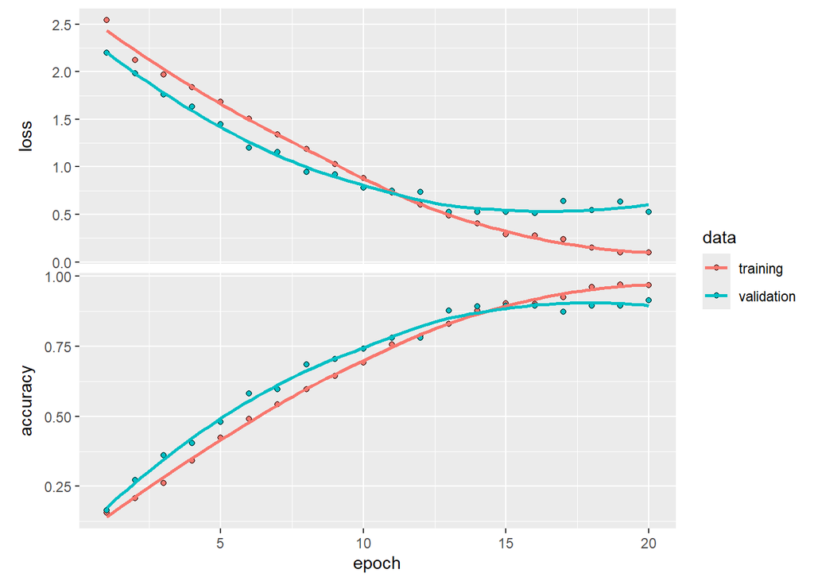

```r
# Callback definition
callbacks_list <- list(
  callback_early_stopping(
    monitor = 'val_loss',
    patience = 8,
    verbose = 0
  ),
  callback_reduce_lr_on_plateau(
    monitor = 'val_loss',
    factor = 0.1,
    patience = 10,
    verbose = 0
  )
)

# Dynamically calculate steps_per_epoch and validation_steps
train_steps <- as.integer(train_generator$n / train_generator$batch_size)
val_steps <- as.integer(validation_generator$n / validation_generator$batch_size)

# Train the model with the generator
history <- model %>% fit_generator(
  train_generator,
  steps_per_epoch = train_steps,
  epochs = 20,
  validation_data = validation_generator,
  validation_steps = val_steps,
  callbacks = callbacks_list
)
# Plot the training history without the lr graph
history_no_lr <- history
history_no_lr$metrics$lr <- NULL

plot(history_no_lr)
```

```r
# To save the model after training
model %>% save_model_hdf5("music_genre_cnn_model.h5")
```

The model seems to be learning effectively as loss decreases while accuracy is improving. There is slight overfitting. Overall the model could be improved fine-tuning some hyperparameters.

```r
score <- model %>% evaluate(
  test_generator)
```

```
## 14/14 - 2s - loss: 0.3843 - accuracy: 0.9250 - 2s/epoch - 141ms/step
```

```r
cat('Test loss:', score[1], '\n')
```

```
## Test loss: 0.3843001
```

```r
cat('Test accuracy:', score[2], '\n')
```

```
## Test accuracy: 0.925
```

The resulting low test loss indicates that the model is performing quite well and making accurate predictions. The high test accuracy means that the model generalize well with unseed data. The performance could be improved with some tuning.

# Hyperparameters tuning and results

In this section tuning is applied to some hyperparameters of the previous CNN. The tuning is based on a predefined search grid with two hyperparameters: the dropout rate and the learning rate. The dropout rate is set either to 0.3 or 0.4, while the learning rate is set to either 0.0001 or 0.001. The values dropout rate = 0.5 and learning rate = 0.0005 were also considered but omitted due to the hight computational cost.

```r
# Define hyperparameter space for tuning
param_grid <- expand.grid(
  dropout1 = c(0.3, 0.4),
  lr = c(0.0001, 0.001)
)

best_model <- NULL
best_val_accuracy <- 0
best_params <- NULL

# Loop through each combination of hyperparameters
for (i in 1:nrow(param_grid)) {
  params <- param_grid[i, ]  # Extract parameters for this run
  cat("\nTraining with parameters:\n", paste(names(params), params, sep = " = ",
                                             collapse = ", "), "\n")

  # Define the model
  model <- keras_model_sequential() %>%
    layer_conv_2d(filters = 32,
                  kernel_size = c(3, 3),
                  activation = "relu", input_shape = c(224, 224, 3)) %>%
    layer_max_pooling_2d(pool_size = c(2, 2)) %>%
    layer_conv_2d(filters = 64,
                  kernel_size = c(3, 3),
                  activation = "relu") %>%
    layer_max_pooling_2d(pool_size = c(2, 2)) %>%
    layer_conv_2d(filters = 128,
                  kernel_size = c(3, 3),
                  activation = "relu") %>%
    layer_max_pooling_2d(pool_size = c(2, 2)) %>%
    layer_conv_2d(filters = 256,
                  kernel_size = c(3, 3),
                  activation = "relu") %>%
    layer_flatten() %>%
    layer_dense(units = 256, activation = "relu") %>%
    layer_dropout(rate = params$dropout1) %>%
    layer_dense(units = 10, activation = "softmax")  # 10 classes as output

  # Compile the model
  model %>% compile(
    loss = 'categorical_crossentropy',
    optimizer = optimizer_adam(learning_rate = params$lr),
    metrics = c('accuracy')
  )

  # Train model
  history <- model %>% fit(
    train_generator,
    steps_per_epoch = train_steps,
    epochs = 20,
    validation_data = validation_generator,
    validation_steps = val_steps,
    verbose = 0
  )
# Evaluate on validation set
  val_acc <- max(history$metrics$val_accuracy)

  cat("Validation Accuracy:", val_acc, "\n")

  # Check if this model is the best so far
  if (val_acc > best_val_accuracy) {
    best_val_accuracy <- val_acc
    best_model <- model
    best_params <- params
  }
}
```

```
##
## Training with parameters:
##  dropout1 = 0.3, lr = 1e-04
## Validation Accuracy: 0.9230769
##
## Training with parameters:
##  dropout1 = 0.4, lr = 1e-04
## Validation Accuracy: 0.9269231
##
## Training with parameters:
##  dropout1 = 0.3, lr = 0.001
## Validation Accuracy: 0.8884615
##
## Training with parameters:
##  dropout1 = 0.4, lr = 0.001
## Validation Accuracy: 0.8807693
```

```r
# Print best parameters
cat("Best Validation Accuracy:", best_val_accuracy, "\n")
```

```
## Best Validation Accuracy: 0.9269231
```

```r
cat("Best Parameters:\n", paste(names(best_params), best_params, sep = " = ",
                                collapse = ", "), "\n")
```

```
## Best Parameters:
##  dropout1 = 0.4, lr = 1e-04
```

```r
# Save the best model
best_model %>% save_model_hdf5("best_music_genre_cnn_model.h5")
```

After the hyperparameter tuning process, the best dropout rate and learning rate are extracted and stored in the variables best_dropout and best_lr.

Then these values are used to define the CNN model with the optimal hyperparameters.

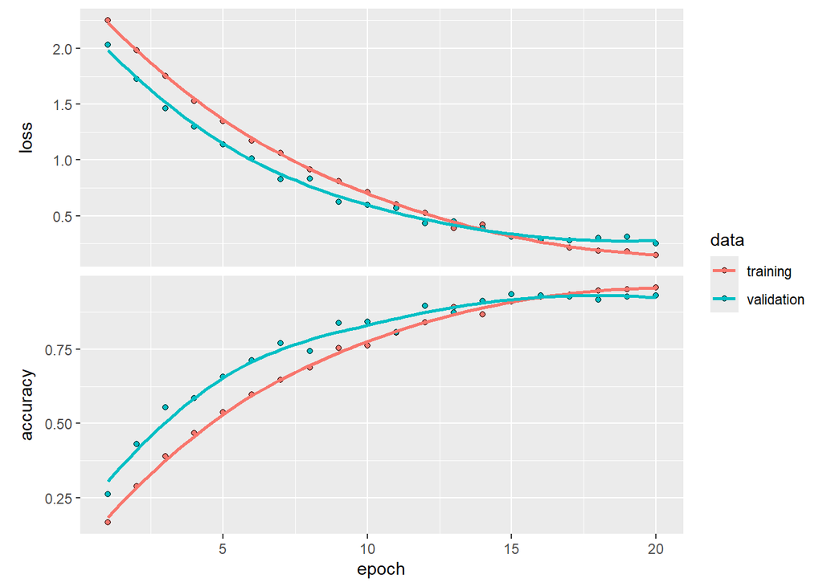

```r
best_dropout <- best_params$dropout1
best_lr <- best_params$lr

model <- keras_model_sequential() %>%

  layer_conv_2d(filters = 32, kernel_size = c(3, 3), activation = 'relu',
  input_shape = c(224, 224, 3)) %>%
  layer_max_pooling_2d(pool_size = c(2, 2)) %>%

  layer_conv_2d(filters = 64, kernel_size = c(3, 3), activation = 'relu') %>%
  layer_max_pooling_2d(pool_size = c(2, 2)) %>%

  layer_conv_2d(filters = 128, kernel_size = c(3, 3), activation = 'relu') %>%
  layer_max_pooling_2d(pool_size = c(2, 2)) %>%

  layer_conv_2d(filters = 256, kernel_size = c(3, 3), activation = 'relu') %>%

  layer_flatten() %>%
  layer_dense(units = 256, activation = 'relu') %>%
  layer_dropout(rate = best_dropout) %>%
  layer_dense(units = 10, activation = 'softmax') # 10 classes as output

model %>% compile(
  loss = 'categorical_crossentropy',
  optimizer = optimizer_adam(learning_rate = best_lr),
  metrics = c('accuracy')
)

history <- model %>% fit_generator(
  train_generator,
  steps_per_epoch = train_steps,
  epochs = 20,
  validation_data = validation_generator,
  validation_steps = val_steps,
  callbacks = callbacks_list
)
# Plot the training history without the lr graph
history_no_lr <- history
history_no_lr$metrics$lr <- NULL

plot(history_no_lr)
```

```r
# To save the model after training
model %>% save_model_hdf5("music_genre_cnn_model_with_best_params.h5")
```

```r
score <- model %>% evaluate(
  test_generator)
```

```
## 14/14 - 2s - loss: 0.2054 - accuracy: 0.9357 - 2s/epoch - 141ms/step
```

```r
cat('Test loss:', score[1], '\n')
```

```
## Test loss: 0.2054104
```

```r
cat('Test accuracy:', score[2], '\n')
```

```
## Test accuracy: 0.9357143
```

# Transfer Learning

## Feature extraction

Feature extraction is a process that involves using the learned presentations from a previously trained network to capture interesting features from new data. These features are then passed through a new classifier, which is trained from scratch to adapt to the new task.

The VGG16 model is very useful for feature extraction because of its structure, pre-training and its ability to generalize well across different tasks.

VGG16 is a Deep Convolutional Neural Network pre-trained on ImageNet, a very large dataset. It is able to recognize a great variety of features that are common in different types of images, making its extraction capabilities easily transferable to different tasks. This allows to leverage pre-existing knowledge.

The first few layers of the model learn basic visual elements, such as texture and edges, while deeper layers capture more complex pattern. This hierarchical structure allows to extract different levels of features depending on the task.

Through the following code the VGG16 architecture can be visualized. It is composed by 5 blocks, each contaning 2 or 3 convolutional layers followed by a pooling layer.

```r
conv_base <- application_vgg16(
  weights = "imagenet",
  include_top = FALSE,
  input_shape = c(224, 224, 3)
)

conv_base
```

```
## Model: "vgg16"
## ________________________________________________________________________________
##  Layer (type)                       Output Shape                    Param #
## ================================================================================
##  input_1 (InputLayer)               [(None, 224, 224, 3)]           0
##  block1_conv1 (Conv2D)              (None, 224, 224, 64)            1792
##  block1_conv2 (Conv2D)              (None, 224, 224, 64)            36928
##  block1_pool (MaxPooling2D)         (None, 112, 112, 64)            0
##  block2_conv1 (Conv2D)              (None, 112, 112, 128)           73856
##  block2_conv2 (Conv2D)              (None, 112, 112, 128)           147584
##  block2_pool (MaxPooling2D)         (None, 56, 56, 128)             0
##  block3_conv1 (Conv2D)              (None, 56, 56, 256)             295168
##  block3_conv2 (Conv2D)              (None, 56, 56, 256)             590080
##  block3_conv3 (Conv2D)              (None, 56, 56, 256)             590080
##  block3_pool (MaxPooling2D)         (None, 28, 28, 256)             0
##  block4_conv1 (Conv2D)              (None, 28, 28, 512)             1180160
##  block4_conv2 (Conv2D)              (None, 28, 28, 512)             2359808
##  block4_conv3 (Conv2D)              (None, 28, 28, 512)             2359808
##  block4_pool (MaxPooling2D)         (None, 14, 14, 512)             0
##  block5_conv1 (Conv2D)              (None, 14, 14, 512)             2359808
##  block5_conv2 (Conv2D)              (None, 14, 14, 512)             2359808
##  block5_conv3 (Conv2D)              (None, 14, 14, 512)             2359808
##  block5_pool (MaxPooling2D)         (None, 7, 7, 512)               0
## ================================================================================
## Total params: 14714688 (56.13 MB)
## Trainable params: 14714688 (56.13 MB)
## Non-trainable params: 0 (0.00 Byte)
## ________________________________________________________________________________
```

Some fully connected layers are added. The final map has shape (7, 7, 512) so a densely connected classifier was first added, followed by a batch normalization layer and the alternation of dropout and dense layers.

```r
batch_size <- 20

datagen <- image_data_generator(rescale = 1/255)

# Function to extract features using VGG16
extract_features <- function(directory, sample_count) {
  features <- array(0, dim = c(sample_count, 7, 7, 512))
  labels <- array(0, dim = c(sample_count, 10))   # 10 classes

generator <- flow_images_from_directory(
  directory = directory,
  generator = datagen,
  target_size = c(224, 224),
  batch_size = batch_size,
  class_mode = "categorical"
)

i <- 0
while(TRUE) {
  batch <- generator_next(generator)
  inputs_batch <- batch[[1]]
  labels_batch <- batch[[2]]
  features_batch <- conv_base %>% predict(inputs_batch)

  index_start <- (i * batch_size) + 1
  index_end <- min((i + 1) * batch_size, sample_count)
  batch_size_actual <- index_end - index_start + 1

  features[index_start:index_end,,,] <- features_batch[1:batch_size_actual,,,]
  labels[index_start:index_end,] <- labels_batch[1:batch_size_actual,]

  i <- i + 1

  if (i * batch_size >= sample_count) break
  }

  list(features = features, labels = labels)
}
```

```r
# Extract features
train <- extract_features(train_dir, 918)
```

```
## Found 918 images belonging to 10 classes.
## 1/1 - 3s - 3s/epoch - 3s/step
## 1/1 - 3s - 3s/epoch - 3s/step
## 1/1 - 2s - 2s/epoch - 2s/step
## 1/1 - 3s - 3s/epoch - 3s/step
## 1/1 - 2s - 2s/epoch - 2s/step
## 1/1 - 3s - 3s/epoch - 3s/step
## 1/1 - 3s - 3s/epoch - 3s/step
## 1/1 - 2s - 2s/epoch - 2s/step
## 1/1 - 2s - 2s/epoch - 2s/step
## 1/1 - 3s - 3s/epoch - 3s/step
## 1/1 - 2s - 2s/epoch - 2s/step
## 1/1 - 2s - 2s/epoch - 2s/step
## 1/1 - 2s - 2s/epoch - 2s/step
## 1/1 - 2s - 2s/epoch - 2s/step
## 1/1 - 3s - 3s/epoch - 3s/step
## 1/1 - 2s - 2s/epoch - 2s/step
## 1/1 - 3s - 3s/epoch - 3s/step
## 1/1 - 2s - 2s/epoch - 2s/step
## 1/1 - 2s - 2s/epoch - 2s/step
## 1/1 - 2s - 2s/epoch - 2s/step
## 1/1 - 2s - 2s/epoch - 2s/step
## 1/1 - 2s - 2s/epoch - 2s/step
## 1/1 - 3s - 3s/epoch - 3s/step
## 1/1 - 2s - 2s/epoch - 2s/step
## 1/1 - 2s - 2s/epoch - 2s/step
## 1/1 - 2s - 2s/epoch - 2s/step
## 1/1 - 2s - 2s/epoch - 2s/step
## 1/1 - 2s - 2s/epoch - 2s/step
## 1/1 - 2s - 2s/epoch - 2s/step
## 1/1 - 2s - 2s/epoch - 2s/step
## 1/1 - 2s - 2s/epoch - 2s/step
## 1/1 - 2s - 2s/epoch - 2s/step
## 1/1 - 2s - 2s/epoch - 2s/step
## 1/1 - 2s - 2s/epoch - 2s/step
## 1/1 - 2s - 2s/epoch - 2s/step
## 1/1 - 2s - 2s/epoch - 2s/step
## 1/1 - 2s - 2s/epoch - 2s/step
## 1/1 - 2s - 2s/epoch - 2s/step
## 1/1 - 2s - 2s/epoch - 2s/step
## 1/1 - 2s - 2s/epoch - 2s/step
## 1/1 - 2s - 2s/epoch - 2s/step
## 1/1 - 2s - 2s/epoch - 2s/step
## 1/1 - 2s - 2s/epoch - 2s/step
## 1/1 - 2s - 2s/epoch - 2s/step
## 1/1 - 2s - 2s/epoch - 2s/step
## 1/1 - 2s - 2s/epoch - 2s/step
```

```r
validation <- extract_features(validation_dir, 273)
```

```
## Found 273 images belonging to 10 classes.
## 1/1 - 2s - 2s/epoch - 2s/step
## 1/1 - 2s - 2s/epoch - 2s/step
## 1/1 - 2s - 2s/epoch - 2s/step
## 1/1 - 2s - 2s/epoch - 2s/step
## 1/1 - 2s - 2s/epoch - 2s/step
## 1/1 - 2s - 2s/epoch - 2s/step
## 1/1 - 2s - 2s/epoch - 2s/step
## 1/1 - 3s - 3s/epoch - 3s/step
## 1/1 - 2s - 2s/epoch - 2s/step
## 1/1 - 2s - 2s/epoch - 2s/step
## 1/1 - 2s - 2s/epoch - 2s/step
## 1/1 - 2s - 2s/epoch - 2s/step
## 1/1 - 2s - 2s/epoch - 2s/step
## 1/1 - 2s - 2s/epoch - 2s/step
```

```r
test <- extract_features(test_dir, 280)
```

```
## Found 280 images belonging to 10 classes.
## 1/1 - 2s - 2s/epoch - 2s/step
## 1/1 - 2s - 2s/epoch - 2s/step
## 1/1 - 2s - 2s/epoch - 2s/step
## 1/1 - 2s - 2s/epoch - 2s/step
## 1/1 - 2s - 2s/epoch - 2s/step
## 1/1 - 2s - 2s/epoch - 2s/step
## 1/1 - 2s - 2s/epoch - 2s/step
## 1/1 - 2s - 2s/epoch - 2s/step
## 1/1 - 2s - 2s/epoch - 2s/step
## 1/1 - 2s - 2s/epoch - 2s/step
## 1/1 - 2s - 2s/epoch - 2s/step
## 1/1 - 2s - 2s/epoch - 2s/step
## 1/1 - 2s - 2s/epoch - 2s/step
## 1/1 - 2s - 2s/epoch - 2s/step
```

```r
# Reshape features for input into the dense layer
reshape_features <- function(features) {
  array_reshape(features, dim = c(nrow(features), 7 * 7 * 512))
}

train$features <- reshape_features(train$features)
validation$features <- reshape_features(validation$features)
test$features <- reshape_features(test$features)

# Define the new model
model <- keras_model_sequential() %>%
  layer_dense(units = 512, activation = "relu", input_shape = 7*7*512,
              kernel_regularizer = regularizer_l2(0.001)) %>%
  layer_batch_normalization() %>%
  layer_dropout(rate = 0.6) %>%
  layer_dense(units = 128, activation = "relu",
              kernel_regularizer = regularizer_l2(0.001)) %>%
  layer_dropout(rate = 0.5) %>%
  layer_dense(units = 10, activation = "softmax")

model %>% compile(
  loss = "categorical_crossentropy",
  optimizer = optimizer_adam(1e-3),
  metrics = c("accuracy")
)

history <- model %>% fit(
  train$features, train$labels,
  epochs = 50,
  batch_size = 20,
  validation_data = list(validation$features, validation$labels),
  callbacks = list(
    callback_early_stopping(monitor = "val_loss", patience = 5),
    callback_reduce_lr_on_plateau(monitor = "val_loss", factor = 0.2, patience = 2)
  )
)
```

```
## 46/46 - 4s - loss: 2.9862 - accuracy: 0.3203 - val_loss: 4.9543 - val_accuracy: 0.2198 - lr: 0.0010 - 4s/epoch - 91ms/step
## 46/46 - 3s - loss: 2.2650 - accuracy: 0.4619 - val_loss: 4.5900 - val_accuracy: 0.2161 - lr: 0.0010 - 3s/epoch - 70ms/step
## 46/46 - 3s - loss: 1.8460 - accuracy: 0.5599 - val_loss: 2.5164 - val_accuracy: 0.3883 - lr: 0.0010 - 3s/epoch - 71ms/step
## 46/46 - 3s - loss: 1.6794 - accuracy: 0.6144 - val_loss: 1.7443 - val_accuracy: 0.6007 - lr: 0.0010 - 3s/epoch - 71ms/step
## 46/46 - 3s - loss: 1.6190 - accuracy: 0.6307 - val_loss: 1.3809 - val_accuracy: 0.7033 - lr: 0.0010 - 3s/epoch - 71ms/step
## 46/46 - 3s - loss: 1.5400 - accuracy: 0.6667 - val_loss: 1.1058 - val_accuracy: 0.8278 - lr: 0.0010 - 3s/epoch - 69ms/step
## 46/46 - 3s - loss: 1.3895 - accuracy: 0.6917 - val_loss: 1.0813 - val_accuracy: 0.8132 - lr: 0.0010 - 3s/epoch - 70ms/step
## 46/46 - 3s - loss: 1.2847 - accuracy: 0.7386 - val_loss: 1.2169 - val_accuracy: 0.7619 - lr: 0.0010 - 3s/epoch - 71ms/step
## 46/46 - 3s - loss: 1.2559 - accuracy: 0.7418 - val_loss: 1.0123 - val_accuracy: 0.8571 - lr: 0.0010 - 3s/epoch - 70ms/step
## 46/46 - 3s - loss: 1.1413 - accuracy: 0.7952 - val_loss: 0.9851 - val_accuracy: 0.8425 - lr: 0.0010 - 3s/epoch - 70ms/step
## 46/46 - 3s - loss: 1.0584 - accuracy: 0.8203 - val_loss: 1.0908 - val_accuracy: 0.8095 - lr: 0.0010 - 3s/epoch - 70ms/step
## 46/46 - 3s - loss: 1.0797 - accuracy: 0.8072 - val_loss: 1.0956 - val_accuracy: 0.8095 - lr: 0.0010 - 3s/epoch - 71ms/step
## 46/46 - 3s - loss: 1.0107 - accuracy: 0.8333 - val_loss: 0.8976 - val_accuracy: 0.9011 - lr: 2.0000e-04 - 3s/epoch - 73ms/step
## 46/46 - 3s - loss: 0.8883 - accuracy: 0.8649 - val_loss: 0.8409 - val_accuracy: 0.9048 - lr: 2.0000e-04 - 3s/epoch - 74ms/step
## 46/46 - 3s - loss: 0.9056 - accuracy: 0.8464 - val_loss: 0.8256 - val_accuracy: 0.9194 - lr: 2.0000e-04 - 3s/epoch - 75ms/step
## 46/46 - 3s - loss: 0.8528 - accuracy: 0.8791 - val_loss: 0.8045 - val_accuracy: 0.9158 - lr: 2.0000e-04 - 3s/epoch - 75ms/step
## 46/46 - 3s - loss: 0.7941 - accuracy: 0.8965 - val_loss: 0.8190 - val_accuracy: 0.9121 - lr: 2.0000e-04 - 3s/epoch - 74ms/step
## 46/46 - 3s - loss: 0.7875 - accuracy: 0.9009 - val_loss: 0.7901 - val_accuracy: 0.9267 - lr: 2.0000e-04 - 3s/epoch - 75ms/step
## 46/46 - 3s - loss: 0.7420 - accuracy: 0.9041 - val_loss: 0.7822 - val_accuracy: 0.9267 - lr: 2.0000e-04 - 3s/epoch - 74ms/step
## 46/46 - 3s - loss: 0.7307 - accuracy: 0.9063 - val_loss: 0.7688 - val_accuracy: 0.9231 - lr: 2.0000e-04 - 3s/epoch - 74ms/step
## 46/46 - 3s - loss: 0.7279 - accuracy: 0.9063 - val_loss: 0.7709 - val_accuracy: 0.9194 - lr: 2.0000e-04 - 3s/epoch - 73ms/step
## 46/46 - 3s - loss: 0.6935 - accuracy: 0.9085 - val_loss: 0.7564 - val_accuracy: 0.9194 - lr: 2.0000e-04 - 3s/epoch - 74ms/step
## 46/46 - 3s - loss: 0.6777 - accuracy: 0.9237 - val_loss: 0.7495 - val_accuracy: 0.9231 - lr: 2.0000e-04 - 3s/epoch - 75ms/step
## 46/46 - 3s - loss: 0.6515 - accuracy: 0.9325 - val_loss: 0.7371 - val_accuracy: 0.9451 - lr: 2.0000e-04 - 3s/epoch - 75ms/step
## 46/46 - 3s - loss: 0.6523 - accuracy: 0.9248 - val_loss: 0.7050 - val_accuracy: 0.9377 - lr: 2.0000e-04 - 3s/epoch - 74ms/step
## 46/46 - 3s - loss: 0.5988 - accuracy: 0.9488 - val_loss: 0.6914 - val_accuracy: 0.9377 - lr: 2.0000e-04 - 3s/epoch - 74ms/step
## 46/46 - 3s - loss: 0.6298 - accuracy: 0.9292 - val_loss: 0.7055 - val_accuracy: 0.9341 - lr: 2.0000e-04 - 3s/epoch - 75ms/step
## 46/46 - 3s - loss: 0.6135 - accuracy: 0.9390 - val_loss: 0.7229 - val_accuracy: 0.9267 - lr: 2.0000e-04 - 3s/epoch - 75ms/step
## 46/46 - 3s - loss: 0.5782 - accuracy: 0.9586 - val_loss: 0.6974 - val_accuracy: 0.9341 - lr: 4.0000e-05 - 3s/epoch - 74ms/step
## 46/46 - 3s - loss: 0.5960 - accuracy: 0.9368 - val_loss: 0.6882 - val_accuracy: 0.9341 - lr: 4.0000e-05 - 3s/epoch - 73ms/step
## 46/46 - 3s - loss: 0.5823 - accuracy: 0.9499 - val_loss: 0.6874 - val_accuracy: 0.9377 - lr: 4.0000e-05 - 3s/epoch - 74ms/step
## 46/46 - 3s - loss: 0.5864 - accuracy: 0.9488 - val_loss: 0.6850 - val_accuracy: 0.9377 - lr: 4.0000e-05 - 3s/epoch - 76ms/step
```

[output cut: 16 more lines]

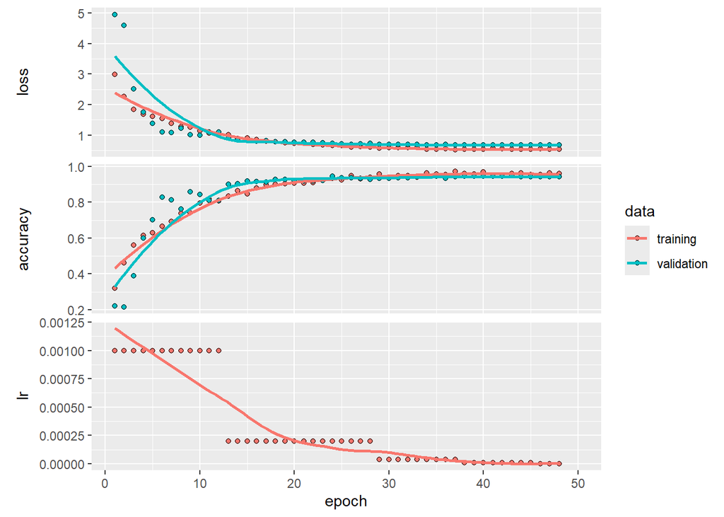

```r
plot(history)
```

```r
# Save the model
model %>% save_model_hdf5("vgg16_transfer_learning.h5")
```

Training and validation accuracy increase over epochs and reach a high value, meaning the model generalizes well.

The learning rate decreases over time, suggesting an adaptive learning schedule.

## Fine tuning

Fine-tuning is a technique used in in deep learning that builds on feature extraction by allowing some layers of a pre-trained model to be updated during training.

While feature extraction consists on using a static feature generator (pre-trained network), fine-tuning unfreezes some of the deeper layers and trains them with the newly added classifier.

This process is very useful for adapting the more abstract representations learned by the pre-trained model to the new task’s specifics.

In the following code, the fine-tuning process is implemented. The function *unfreeze_weights(conv_base, from = “block3_conv1”)* is used to selectively unfreeze layers from *block3_conv1* onward, which means that only the deeper layers can be trained. Batch Normalization layers are explicitly kept frozen.

After these modifications, the model is compiled again with a relatively low learning rate. The reduced learning rate helps to prevent the model from making drastic updates to the learned weights, preserving the pre-trained network’s knowledge.

```r
unfreeze_weights(conv_base, from = "block3_conv1")

for (layer in model$layers) {
  if (inherits(layer, "BatchNormalization")) {
    layer$trainable <- FALSE
  }
}

model %>% compile(
  loss = "categorical_crossentropy",
  optimizer = optimizer_adam(1e-4),
  metrics = c("accuracy")
)


# Train again with fine-tuning
history_finetune <- model %>% fit(
  train$features, train$labels,
  epochs = 20,
  batch_size = 20,
  validation_data = list(validation$features, validation$labels),
  callbacks = list(
    callback_early_stopping(monitor = "val_loss", patience = 5),
    callback_reduce_lr_on_plateau(monitor = "val_loss", factor = 0.2, patience = 2)
  )
)
```

```
## 46/46 - 4s - loss: 0.5238 - accuracy: 0.9641 - val_loss: 0.6466 - val_accuracy: 0.9377 - lr: 1.0000e-04 - 4s/epoch - 91ms/step
## 46/46 - 4s - loss: 0.4952 - accuracy: 0.9532 - val_loss: 0.6434 - val_accuracy: 0.9451 - lr: 1.0000e-04 - 4s/epoch - 80ms/step
## 46/46 - 4s - loss: 0.4934 - accuracy: 0.9532 - val_loss: 0.6668 - val_accuracy: 0.9231 - lr: 1.0000e-04 - 4s/epoch - 83ms/step
## 46/46 - 3s - loss: 0.4731 - accuracy: 0.9586 - val_loss: 0.6344 - val_accuracy: 0.9267 - lr: 1.0000e-04 - 3s/epoch - 73ms/step
## 46/46 - 3s - loss: 0.4525 - accuracy: 0.9728 - val_loss: 0.6287 - val_accuracy: 0.9231 - lr: 1.0000e-04 - 3s/epoch - 72ms/step
## 46/46 - 3s - loss: 0.4703 - accuracy: 0.9608 - val_loss: 0.6333 - val_accuracy: 0.9267 - lr: 1.0000e-04 - 3s/epoch - 72ms/step
## 46/46 - 3s - loss: 0.4479 - accuracy: 0.9728 - val_loss: 0.6272 - val_accuracy: 0.9267 - lr: 1.0000e-04 - 3s/epoch - 71ms/step
## 46/46 - 3s - loss: 0.4396 - accuracy: 0.9597 - val_loss: 0.6125 - val_accuracy: 0.9304 - lr: 1.0000e-04 - 3s/epoch - 72ms/step
## 46/46 - 3s - loss: 0.4282 - accuracy: 0.9684 - val_loss: 0.6245 - val_accuracy: 0.9377 - lr: 1.0000e-04 - 3s/epoch - 72ms/step
## 46/46 - 3s - loss: 0.4247 - accuracy: 0.9662 - val_loss: 0.6217 - val_accuracy: 0.9341 - lr: 1.0000e-04 - 3s/epoch - 73ms/step
## 46/46 - 3s - loss: 0.4149 - accuracy: 0.9749 - val_loss: 0.6173 - val_accuracy: 0.9377 - lr: 2.0000e-05 - 3s/epoch - 71ms/step
## 46/46 - 3s - loss: 0.4199 - accuracy: 0.9728 - val_loss: 0.6158 - val_accuracy: 0.9377 - lr: 2.0000e-05 - 3s/epoch - 71ms/step
## 46/46 - 3s - loss: 0.4414 - accuracy: 0.9630 - val_loss: 0.6111 - val_accuracy: 0.9377 - lr: 4.0000e-06 - 3s/epoch - 71ms/step
## 46/46 - 3s - loss: 0.4190 - accuracy: 0.9662 - val_loss: 0.6087 - val_accuracy: 0.9377 - lr: 4.0000e-06 - 3s/epoch - 71ms/step
## 46/46 - 3s - loss: 0.4045 - accuracy: 0.9793 - val_loss: 0.6091 - val_accuracy: 0.9377 - lr: 4.0000e-06 - 3s/epoch - 71ms/step
## 46/46 - 3s - loss: 0.4073 - accuracy: 0.9739 - val_loss: 0.6088 - val_accuracy: 0.9377 - lr: 4.0000e-06 - 3s/epoch - 72ms/step
## 46/46 - 3s - loss: 0.4163 - accuracy: 0.9728 - val_loss: 0.6075 - val_accuracy: 0.9377 - lr: 8.0000e-07 - 3s/epoch - 73ms/step
## 46/46 - 3s - loss: 0.3920 - accuracy: 0.9826 - val_loss: 0.6068 - val_accuracy: 0.9414 - lr: 8.0000e-07 - 3s/epoch - 72ms/step
## 46/46 - 3s - loss: 0.4054 - accuracy: 0.9771 - val_loss: 0.6062 - val_accuracy: 0.9414 - lr: 8.0000e-07 - 3s/epoch - 71ms/step
## 46/46 - 3s - loss: 0.4173 - accuracy: 0.9706 - val_loss: 0.6058 - val_accuracy: 0.9414 - lr: 8.0000e-07 - 3s/epoch - 71ms/step
```

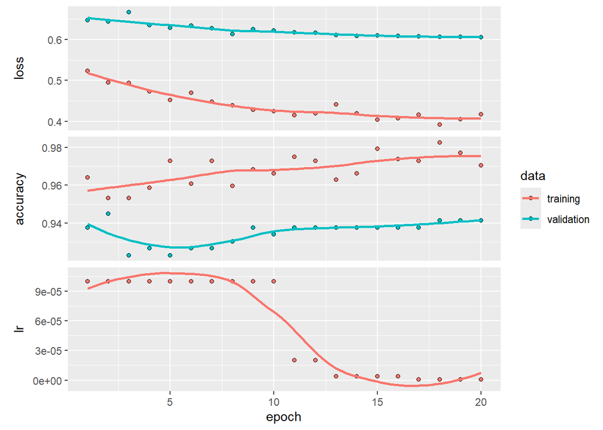

```r
# Plot fine-tuning history
plot(history_finetune)
```

# Feed-forward Neural Network

The GTZAN images can also be processed with a Feed-forward Neural Network, which consists of a flatten layer followed by a sequence of dense and dropout layers.

```r
# Define a Feedforward Neural Network model
model_ff <- keras_model_sequential() %>%
  layer_flatten(input_shape = c(224, 224, 3)) %>%   # Flatten the 224x224x3 input image
  layer_dense(units = 1024, activation = "relu") %>%
  layer_dropout(rate = 0.4) %>%
  layer_dense(units = 512, activation = "relu") %>%
  layer_dropout(rate = 0.4) %>%
  layer_dense(units = 256, activation = "relu") %>%
  layer_dropout(rate = 0.4) %>%
  layer_dense(units = 128, activation = "relu") %>%
  layer_dropout(rate = 0.4) %>%
  layer_dense(units = 10, activation = "softmax")  # Output layer for 10 genres

model_ff %>% compile(
  loss = "categorical_crossentropy",
  optimizer = optimizer_adam(0.001),
  metrics = c("accuracy")
)

summary(model_ff)
```

```
## Model: "sequential_7"
## ________________________________________________________________________________
##  Layer (type)                       Output Shape                    Param #
## ================================================================================
##  flatten_6 (Flatten)                (None, 150528)                  0
##  dense_19 (Dense)                   (None, 1024)                    154141696
##  dropout_11 (Dropout)               (None, 1024)                    0
##  dense_18 (Dense)                   (None, 512)                     524800
##  dropout_10 (Dropout)               (None, 512)                     0
##  dense_17 (Dense)                   (None, 256)                     131328
##  dropout_9 (Dropout)                (None, 256)                     0
##  dense_16 (Dense)                   (None, 128)                     32896
##  dropout_8 (Dropout)                (None, 128)                     0
##  dense_15 (Dense)                   (None, 10)                      1290
## ================================================================================
## Total params: 154832010 (590.64 MB)
## Trainable params: 154832010 (590.64 MB)
## Non-trainable params: 0 (0.00 Byte)
## ________________________________________________________________________________
```

```r
callback_earlystop <- callback_early_stopping(monitor = "val_loss", patience = 10)

callback_lr_scheduler <- callback_reduce_lr_on_plateau(
  monitor = "val_loss", factor = 0.5, patience = 3, min_lr = 1e-6)

# Training Data Generator
train_generator_ff <- flow_images_from_directory(
  train_dir,
  datagen,
  target_size = c(224, 224),
  batch_size = 64,
  class_mode = "categorical"
)
```

```
## Found 918 images belonging to 10 classes.
```

```r
# Validation Data Generator
validation_generator_ff <- flow_images_from_directory(
  validation_dir,
  test_datagen,
  target_size = c(224, 224),
  batch_size = 64,
  class_mode = "categorical"
)
```

```
## Found 273 images belonging to 10 classes.
```

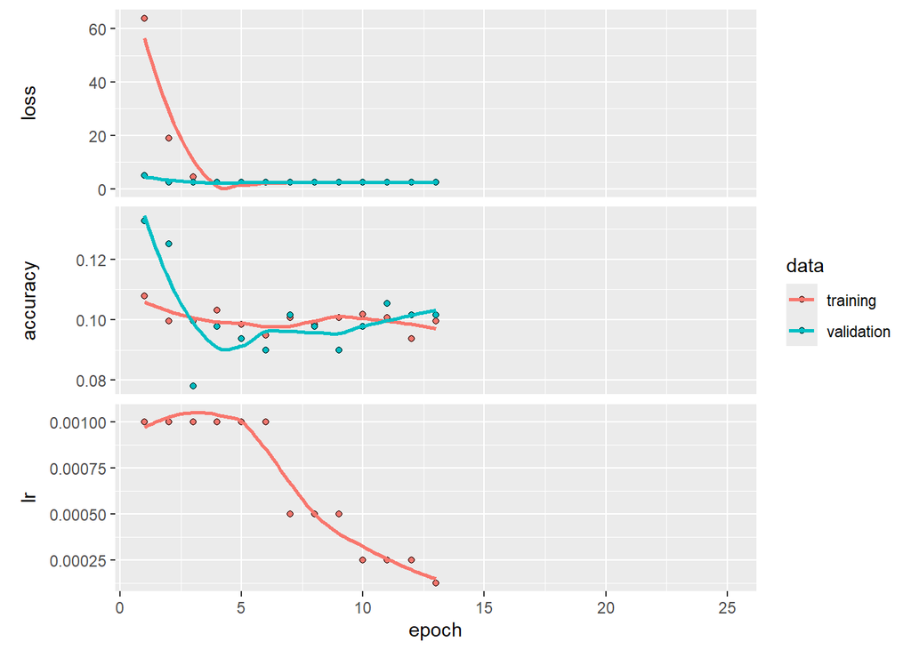

```r
train_steps_ff <- as.integer(train_generator_ff$n / train_generator_ff$batch_size)
val_steps_ff <- as.integer(validation_generator_ff$n / validation_generator_ff$batch_size)

history <- model_ff %>% fit_generator(
  train_generator_ff,
  steps_per_epoch = train_steps_ff,
  epochs = 25,
  validation_data = validation_generator_ff,
  validation_steps = val_steps_ff,
  callbacks = list(callback_earlystop, callback_lr_scheduler),
  verbose = 0
)

plot(history)
```

```r
score <- model_ff %>% evaluate(
  test_generator)
```

```
## 14/14 - 1s - loss: 2.3025 - accuracy: 0.1036 - 1s/epoch - 98ms/step
```

```r
cat('Test loss:', score[1], '\n')
```

```
## Test loss: 2.302486
```

```r
cat('Test accuracy:', score[2], '\n')
```

```
## Test accuracy: 0.1035714
```

The test accuracy remains low, meaning that the network struggles to learn meaningful patterns. In fact one major limitation of FFNNs is that they treat each pixel as an independent input, ignoring the fact that neighboring pixels might contain correlated information. On the other hand, CNNs use convolutional layers to captures patterns (edges, shapes, textures) in the data.

CNNs also require less parameters because they use weight sharing through filters, whereas FFNNs require a weight for every connection.

# Conclusion and Future Developements

In this study, the main goal was to reduce overfitting in a model trained on the GTZAN image dataset.

Firstly, a shallow Convolutional Neural Network (CNN) was applied. After hyperparameter tuning the performance slightly improved.

The next step involved using transfer learning with VGG16 (deep NN), with a focus on feature extraction and fine-tuning. While this led to a slight improvement in accuracy, it was not enough to get a significant performance improvement.

It was then made an attempt to apply a Feedforward Neural Network (FFNN), however, this approach was not successful due to the limitations of FFNNs in capturing spatial hierarchies within the data.

In future work a promising direction could be leveraging the dataset’s audio features. By incorporating audio signal characteristics the model could learn detailed representations.

In addition, Recurrent Neural Networks (RNNs) could be applied to capture temporal dependencies within the audio file.

Combining these techniques with further model optimization and transfer learning, could help address the challenges encountered during this analysis and achieving better results.

## References

- The dataset used in this analysis is available on Kaggle at the following link https://www.kaggle.com/datasets/andradaolteanu/gtzan-dataset-music-genre-classification/data
- Borrotti, M. (2025) *Statistical Learning*, Università degli studi di Milano-Bicocca https://elearning.unimib.it/course/view.php?id=55091
- Hastie, T., Tibshirani, R., & Friedman, J. (2017). *The elements of statistical learning*. Springer.